# Analyzing Rates and Trends of Vaccine Preventable Diseases in California, 2001-2022

PM 566 Midterm, Fall 2024, University of Southern California

Author

Kendall Dimson

## Introduction

I explored the dataset called “Vaccine Preventable Disease Cases by County and Year” collected from the California Department of Public Health (CDPH). The dataset is a summary of case counts that were reported from the 59 counties in California. In this project, various research questions formulated include: Of the top five vaccine preventable disease cases reported in California in the last decades, were there any disease epidemics in specific counties? Is there a geographical relationship between location and case incidence of the vaccine preventable disease with the highest count?

## Methods

Diphtheria, Invasive Meningococcal Disease, Measles, Pertussis, Tetanus, Mumps, Rubella, Hepatitis A, Acute Hepatitis B, Acute Hepatitis C, Varicella Hospitalizations, Varicella Hospitalization/Death, Chronic Hepatitis B, Haemophilus influenzae, Perinatal Hepatitis B, and Rubella (Congenital Syndrome).

In the data cleaning and wrangling step, I removed counties that record 0 cases of a disease, so that the preliminary analysis is focused on counties that did report disease counts. I created a variety of subset datasets. I subsetted the “california” and “county” datasets since there are some categories in “County” variable that have summation number of diseases in California. For each of these I used the filter() function to subset. I used the kable() function to print a table of the total number of vaccine preventable diseases reported in the entirety of the dataset. When analyzing the top 5 diseases reported, I subsetted each into individual datasets, used the arrange() function to print the top five counties of each disease, then created several ggplot barplots to visualize the trend in incidence counts over the years. To analyze the distribution of pertussis cases by counties, I used the leaflet package to code an interactive heat map.

## Preliminary Results

Table 1. Total Cases of Vaccine-Preventable Diseases Reported in California, 2001-2022

| Disease | Total Cases |
| --- | --- |
| Pertussis | 57219 |
| Hepatitis B, Chronic | 4462 |
| Hepatitis A | 3035 |
| Invasive Meningococcal Disease | 2718 |
| Hepatitis B, Acute | 1349 |
| Mumps | 1108 |
| Hepatitis C, Acute | 1050 |
| Measles | 521 |
| Varicella Hospitalizations | 406 |
| Varicella Hospitalization/Death | 93 |
| Tetanus | 86 |
| Rubella | 9 |
| Diphtheria | 2 |

There were a total of 72,058 incident vaccine preventable cases recorded. The top five in total cases reported were Pertussis (n=57,219), Hepatitis B, chronic (n=4462) and acute (n=1349), Invasive Meningococcal Disease (n=2718), and Hepatitis A (n=3035).

Among the documented Pertussis cases in California, the top five counts of annual reported Pertussis cases occurred in Los Angeles county, which recorded a Pertussis epidemic specifically in 2010, 2014, and 2019 (Figure 1).

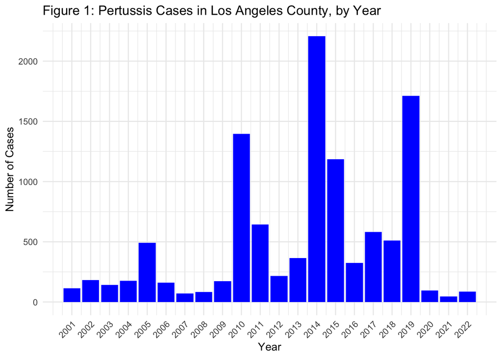

Among Chronic Hepatitis B cases, the top five counts of annual reported cases occurred in Los Angeles, Orange, and Kern counties. Los Angeles reported 1064 cases of Chronic HBV in 2022 and 970 cases in 2021. There were data limitations in exploring trends in Chronic Hepatitis B incidence cases because most of the data was recorded from 2021-2022, lacking adequate data to estimate temporality.

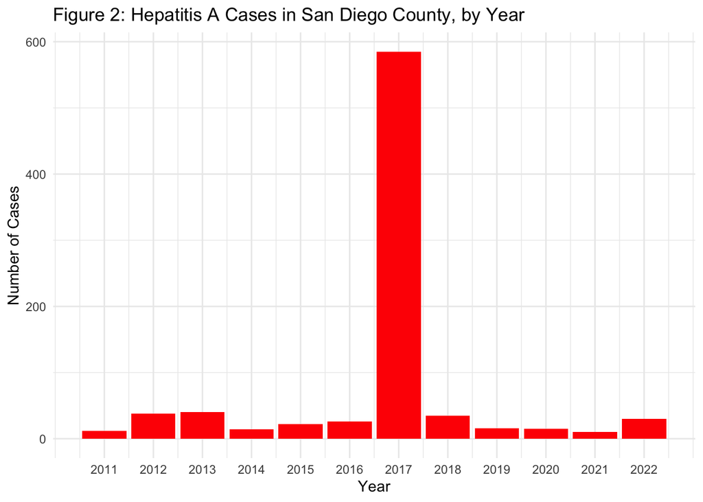

Among Invasive Meningococcal Disease cases, all of the top annual reportings occurred in Los Angeles County in 2001-2002 (n=125), 2005-2006 (n=86), and 2011 (n=37). However, Los Angeles county has had a negative trend in Invasive Meningococcal Disease cases in the last two decades.

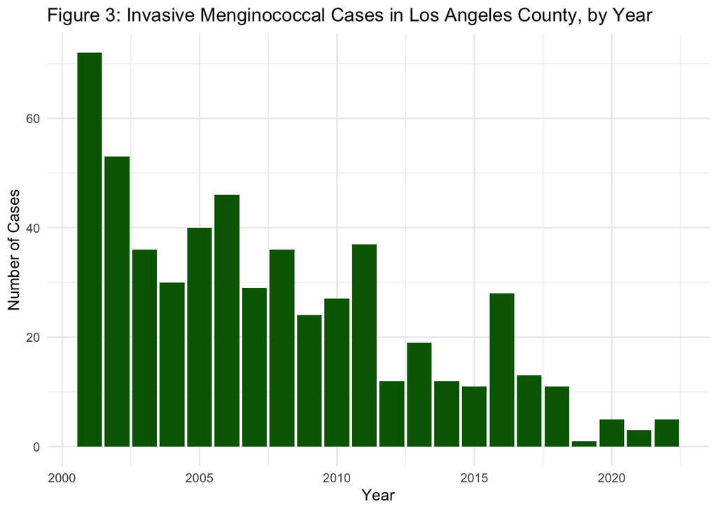

Among cases with Acute Hepatitis B, the most counts of annual reported also occured in Los Angeles county from 2011 and 2013-2016 (n=268). In this region, there is a slight downward trend of acute HBV reporting as well (Figure 4).

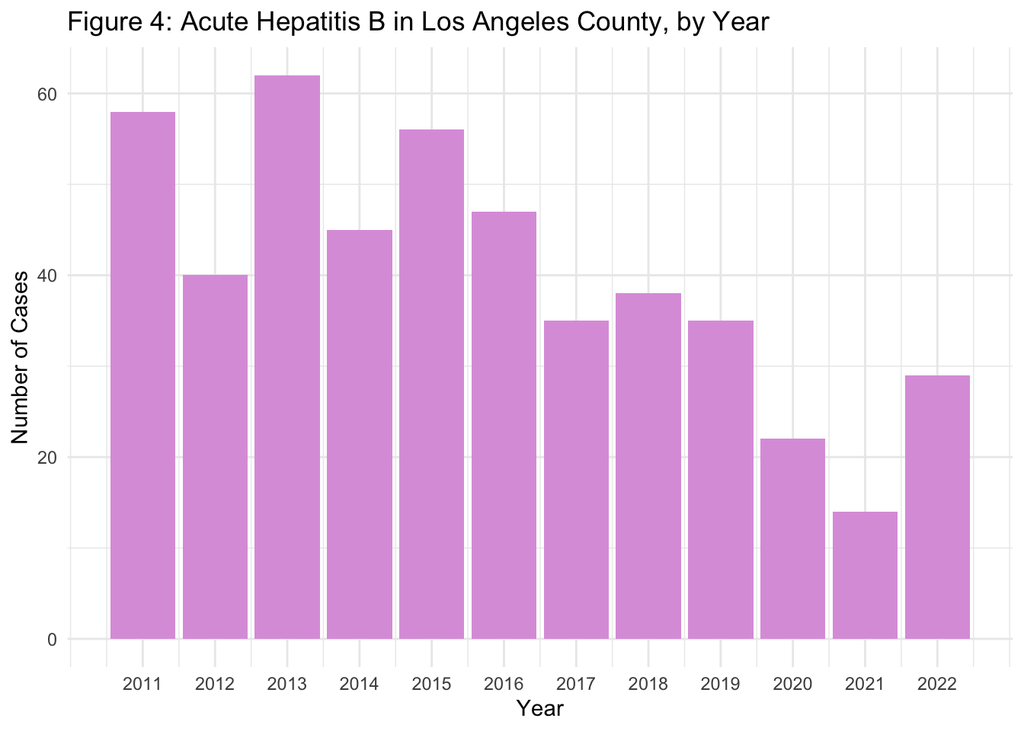

Since pertussis has the greatest incidence disease cases reported, using a heat map by county location in California, it is another visual such that the highest incidence numbers have been reported in Los Angeles county (n=10,956) and San Diego county (n=9,759).

[interactive chart not shown]

## Conclusion

Of the main vaccine preventable disease cases, Los Angeles county was highlighted with high number of case incidence counts annually in regards to Pertussis, Invasive Meningococcal Disease, and Acute/Chronic Hepatitis B. San Diego county reported an epidemic of Hepatitis A in 2017. This data provides interesting insight into trends of Vaccine Preventable Disease Cases in California. It has great potential in future analyses, including: comparison of two or more counties in a specific disease, supplementing incidence case numbers with researching implementation of intervention programs, and more. Another interesting future research topic would be to analyze the vaccine preventable disease case counts in California in comparison to another U.S. state, or national statistics as well.